# Document de synthèse

Besoins de prise en charge en santé mentale des enfants confiés à l’ASE des Yvelines

## Contexte épidémiologique

Les données épidémiologiques récentes montrent que 50% des troubles de santé mentale apparaissent avant l’âge de 20 ans, avec un pic autour de 15 ans chez les filles et les garçons (McGrath et al., 2023, DOI: https://doi.org/10.1016/S2215-0366(23)00193-1). En Europe, environ 16% des jeunes de 10 à 19 ans souffrent d’un trouble mental, selon une analyse de l’UNICEF basée sur les estimations de l’Institute for Health Metrics and Evaluation (IHME), Global Burden of Disease Study, 2019.

Cette prévalence est plus de trois fois plus élevée chez les jeunes pris en charge par les services de protection de l’enfance. Une méta-analyse récente, compilant 27 études menées dans plusieurs pays européens (dont la France) et aux Etats-Unis, révèle qu’en moyenne 46 % des enfants de 4 à 19 ans placés en foyer ou en famille d’accueil présentent au moins un trouble mental (Westlake et al., 2023, DOI: 10.1177/25161032231202256).

## Objectif de la présente synthèse

Le présent document vise à prendre la mesure des besoins en santé mentale des enfants confiés à l’Aide Sociale à l’Enfance (ASE) dans le département des Yvelines. Il examine d’abord l’évolution du nombre total d’enfants placés à l’ASE, leur répartition selon des critères démographiques (âge et genre) et géographiques (commune de résidence). Nous évaluons ensuite, pour l’année 2023, la répartition de cet effectif par commune de résidence ainsi que plusieurs métriques autres que les effectifs bruts, affinant notre représentation des inégalités territoriales en termes de besoins socio-éducatifs. Puis, sur la base des prévalences issues du travail de Westlake et collaborateurs (2023, DOI: 10.1177/25161032231202256), nous dérivons une estimation théorique des besoins en santé mentale des enfants et des jeunes placés, au niveau global et au niveau des territoires. Nous concluons le document par une série de projections des besoins en santé mentale à 5 ans, envisageant plusieurs scenarii d’évolution de la population d’enfants placés par rapport à l’année 2022.

*NB : En raison du manque de données détaillées sur les prévalences par tranche d’âge et genre, nos estimations des besoins en santé mentale sont réalisées de manière globale. Pour minimiser les biais, nous avons focalisé l’analyse sur les enfants soumis à des mesures comparables à celles étudiées dans la méta-analyse de Westlake. Celles-ci sont les suivantes :*

- *PCJ à ASE 78 par Jugement*
- *PCA Mineur*
- *PCJ à ASE 78 par OPP du JE*
- *AEMO Renforcée*
- *SIAA - Pupille à Titre Définitif*
- *DAP JAF Totale au CD78*
- *PCJ à ASE Hors 78*
- *Tutelle déférée au CD78*
- *Délaissement parental*
- *DAP JAF à particulier ou organisme*
- *SIAA - Pup. Prov. Filiation Inconnue/Non-établie*
- *SIAA - Pupille Provisoire Orphelin*
- *SIAA - Pupille Provisoire Remise d’Enfant*
- *PCJ à ASE 78 (code de justice pénale des mineurs)*
- *SIAA- Pupille Provisoire Retrait AP art.380CC*
- *PCJ à ASE 78 (Ordonnance 45)*
- *DAP JAF Partielle à CD78*

*PCJ : Placement Confié au Juge*  
*PCA : Placement à la collectivité ou à un accueil*  
*AEMO : Action Éducative en Milieu Ouvert*  
*DAP : Délégation de l’autorité Parentale*  
*JAF : Juge aux Affaires Familiales*  
*OPP : Ordonnance de Placement Provisoire*  
*JE : Juge des Enfants*  
*SIAA : Service d’Information et d’Adoption Agréé*

## Evolution du nombre d’enfants accueillis par l’ASE

### Nombre d’enfants faisant l’objet d’une mesure de placement

Le graphique ci-dessous met en lumière l’évolution du nombre d’enfants et de jeunes placés en foyer ou en famille d’accueil dans le département des Yvelines entre 2002 et 2022. Les données sont issues de l’enquête “Aide Sociale à l’Enfance” de la DREES, disponibles en open data ([Base de données brutes](https://data.drees.solidarites-sante.gouv.fr/explore/dataset/bases-de-donnees-brutes-de-l-enquete-aide-sociale-volet-aide-sociale-a-l-enfance/information/), [Open dataset](https://data.drees.solidarites-sante.gouv.fr/explore/dataset/les-beneficiaires-de-l-aide-sociale-a-l-enfance/information/)). Après une diminution jusqu’en 2005 puis une longue période de relative stabilité, on assiste à partir de 2018 à une augmentation significative de l’effectif.

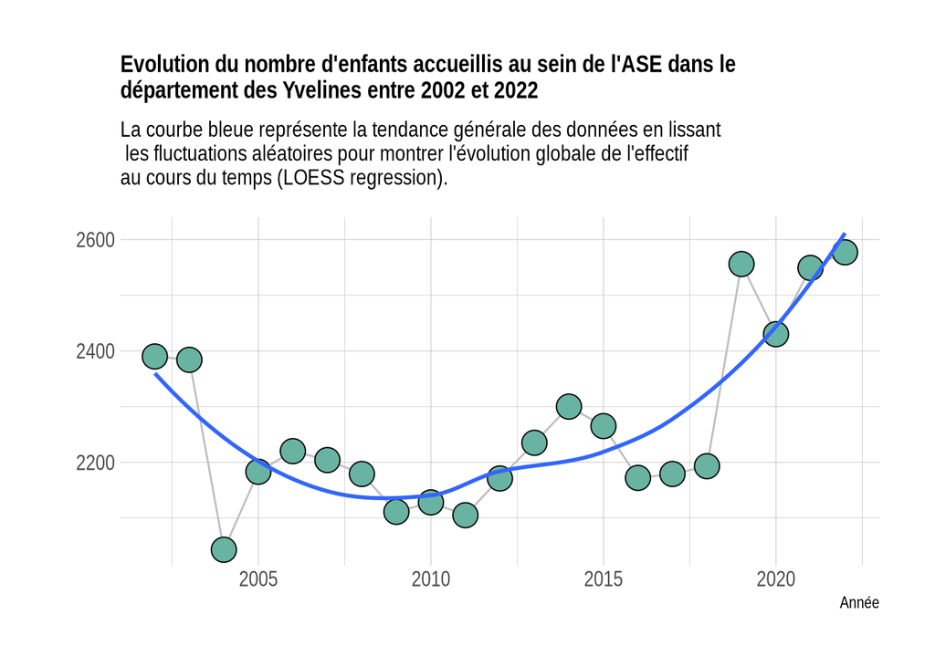

Comme le montre le second graphique, sur cette période de cinq ans (2018-2022), les garçons sont plus nombreux que les filles. Cependant, les deux groupes connaissent une progression similaire, avec 200 enfants supplémentaires dans chaque catégorie en 2022 (garçons : N ~ 1500 ; filles : N ~ 1100) par rapport à 2018 (garçons : N ~ 1300 ; filles : N ~ 900). L’augmentation massive des placements observés concerne donc autant les garçons que les filles.

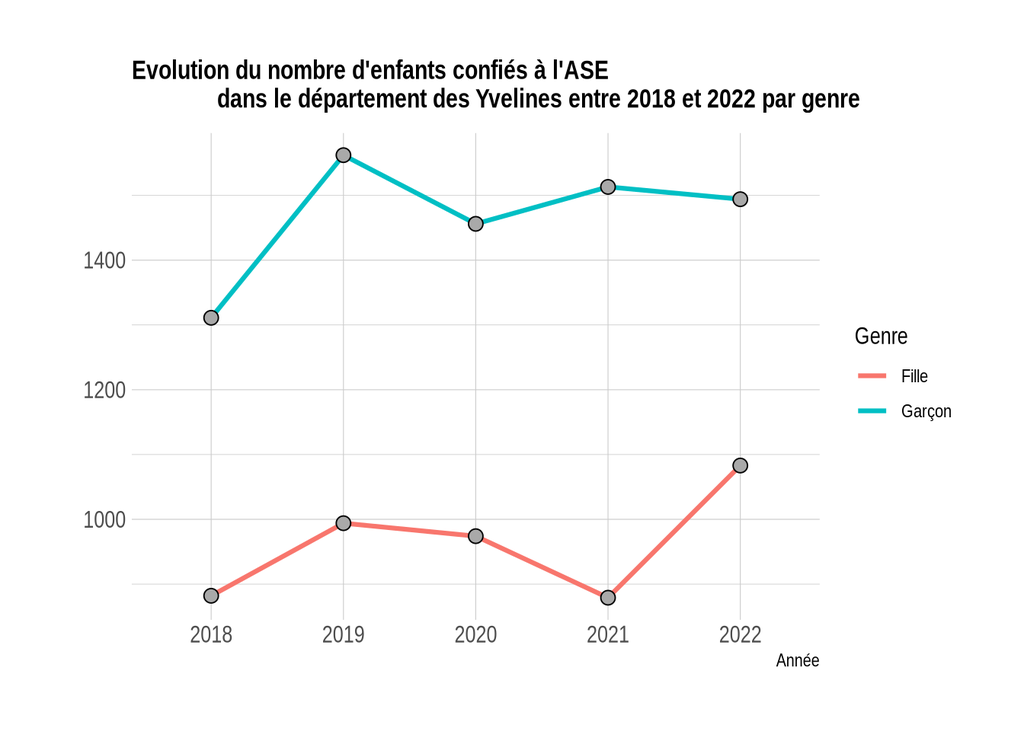

Cette hausse s’accompagne nécessairement d’une augmentation des besoins en santé mentale, puisque près d’un enfant protégé sur deux présente au moins un trouble psychique. Toutes les classes d’âge pourraient être touchées, comme l’analyse suivante le révèle.

Le troisième graphique présente des données stratifiées par tranches d’âge. Il montre que l’augmentation constatée est principalement portée par les enfants de 16 à 17 ans, les jeunes majeurs et, dans une moindre mesure, les enfants de 6 à 10 ans. Bien que leur nombre reste relativement stable, les enfants de 11 à 15 ans représentent toujours un effectif élevé. Enfin, les enfants de moins de 6 ans sont les moins nombreux.

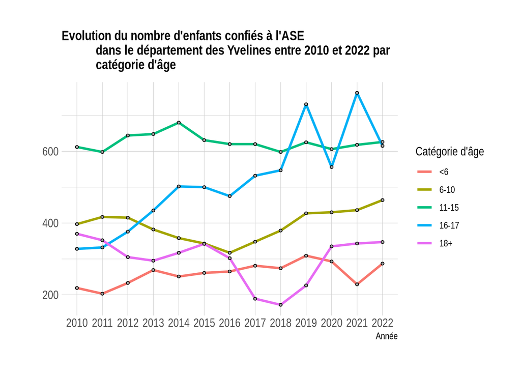

## Représentations territoriales

Les cartes qui suivent montrent la distribution géographique des enfants concernés par une mesure de placement ASE au 31 décembre 2023 (file active) dans le département des Yvelines, tout d’abord sans distinction d’âge, puis selon 5 catégories d’âge : moins de 3 ans, 3-5 ans, 6-10 ans, 11-15 ans et 16-18 ans.

Les tailles et les couleurs des cercles permettent d’observer des disparités géographiques dans le département. Pour des raisons de lisibilité, et comme l’amplitude des valeurs à représenter dépend de la variable étudiée, l’échelle utilisée varie d’une carte à l’autre. On ne peut donc pas comparer les cartes entre elles uniquement sur la base du code couleur. Il faut se référer systématiquement à la légende de chaque carte pour voir à quelle valeur correspondent une taille et une couleur de cercle données.

### Distribution globale

La carte ci-dessous, informant sur la répartition des enfants placés dans les Yvelines, révèle une concentration récurrente dans certaines communes. Versailles apparaît comme la commune la plus touchée, avec des effectifs particulièrement élevés d’enfants concernés. À un niveau légèrement inférieur, des communes et leur périphérie, comme Mantes-la-Jolie, Jambville, Les Mureaux, Saint-Germain-en-Laye, Elancourt, et Plaisir, enregistrent également des nombres importants de placements, soulignant des besoins persistants en matière de protection de l’enfance. Par contraste, des inégalités territoriales marquées se dessinent. Les aires urbaines et péri-urbaines du nord, du nord-est et de l’est apparaissent comme des zones critiques, à l’inverse des aires rurales et périphériques de l’ouest, du centre et du sud du département. Cette situation pourrait s’expliquer par une densité de population plus faible dans ces territoires (voir la carte des effectifs relatifs à la taille des communes de résidence), mais également par des lacunes dans le signalement des situations à risque.

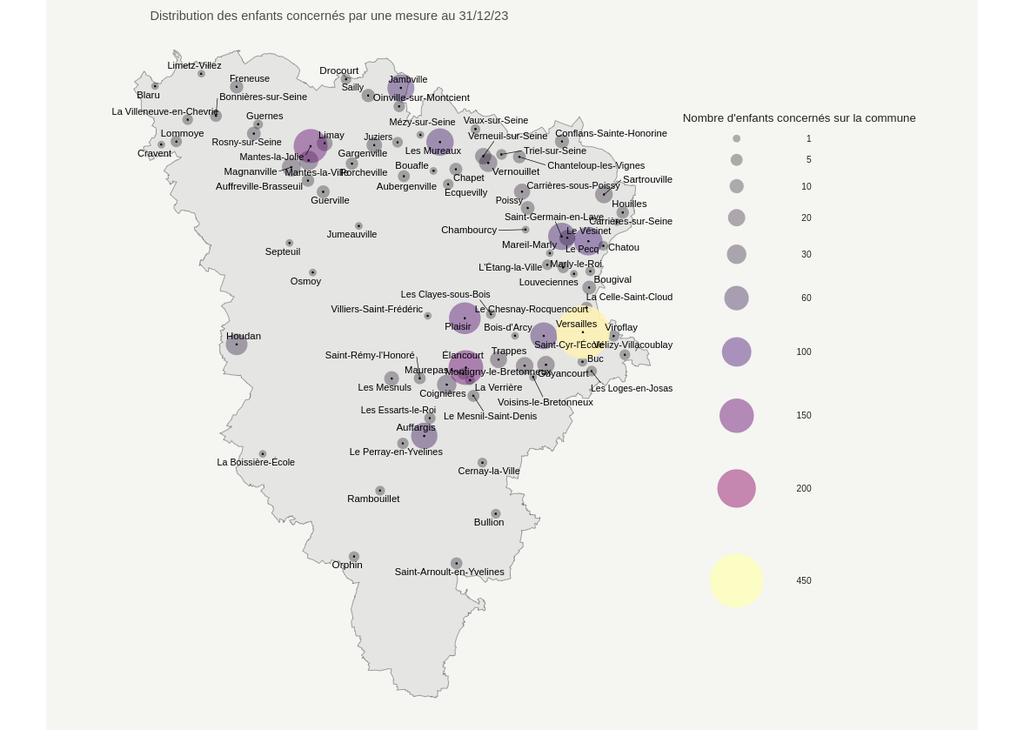

### Distribution par âge

#### Moins de 3 ans

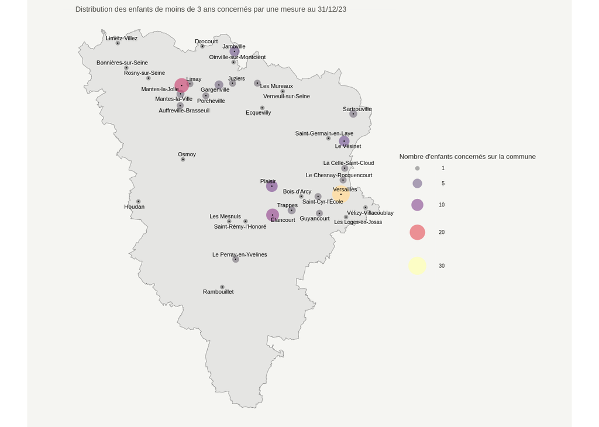

#### Entre 3 et 5 ans

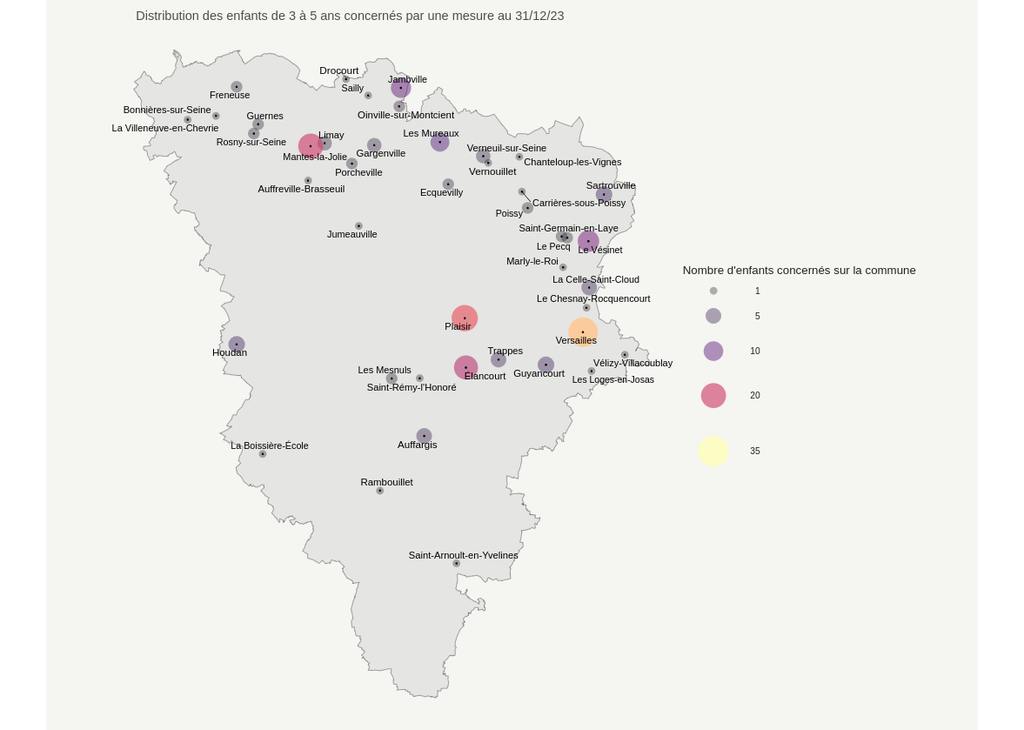

#### Entre 6 et 10 ans

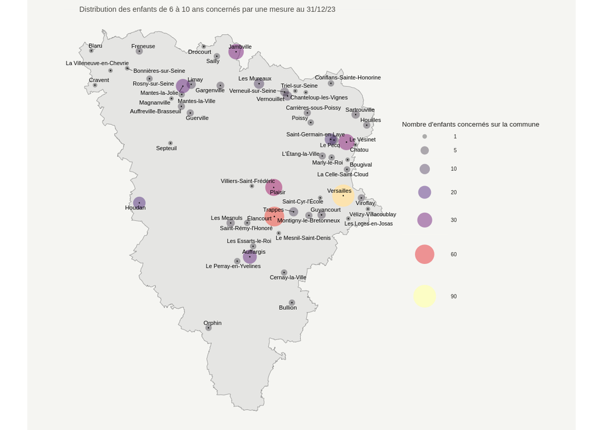

#### Entre 11 et 15 ans

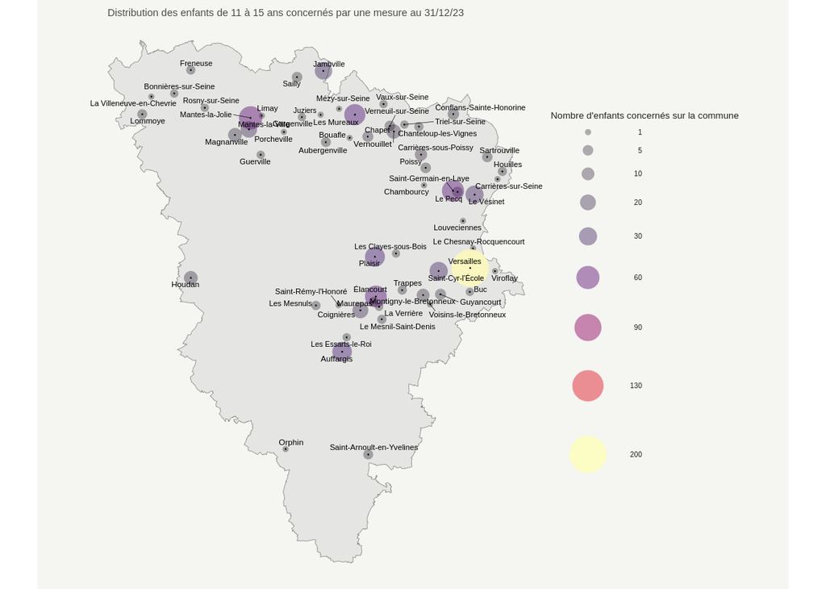

#### Entre 16 et 18 ans

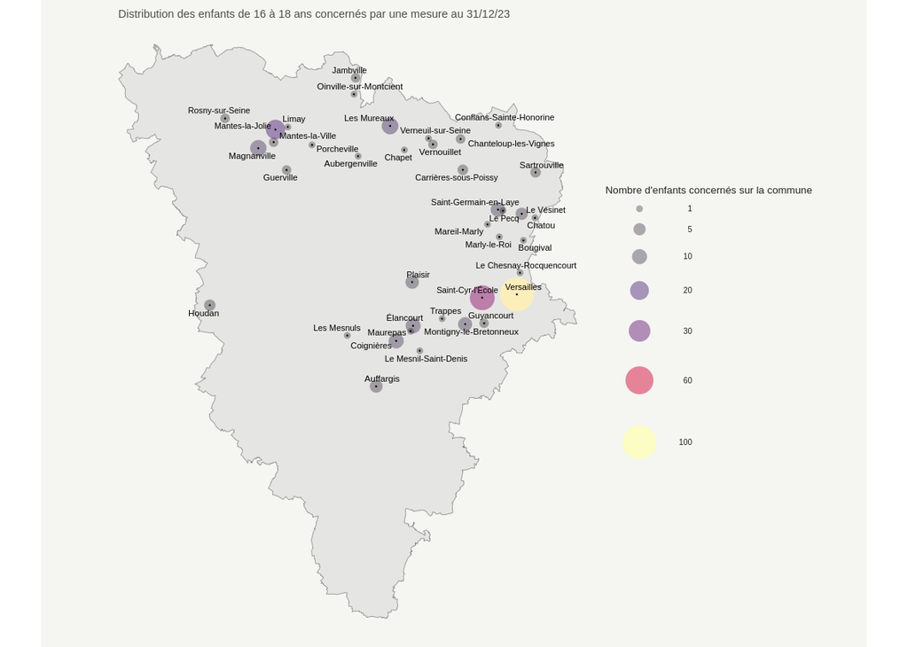

### Nombres d’enfants concernés par une mesure pour 1000 hab

La carte suivante propose une représentation du nombre de mesures de placement en cours (file active) pour 1000 habitants dans les communes de résidence des enfants placés, révélant là encore d’importantes disparités territoriales.

Jambville se distingue par une valeur exceptionnellement élevée (~ 100 enfants/1000 habitants), indiquant une forte proportion relative de placements par rapport à sa population. Des communes comme Auffargis présente également un taux notable, soulignant des besoins importants (~ 40 enfants/1000 habitants). Malgré leur taille modeste, certaines communes rurales ou périurbaines, telles que Sailly, Houdan, Les Mesnuls ou Auffreville-Brasseuil affichent des taux non négligeables (~ 10-15 enfants/1000 habitants). Les communes urbaines comme Versailles, Mantes-la-Jolie, ou Trappes, bien que densément peuplées et touchées en effectifs absolus, affichent des taux de placement modérés au regard de leur population totale.

La présence de taux élevés dans des communes de petite et moyenne taille peut s’expliquer par une densité de population réduite, des différences dans les dynamiques de signalement, ou plus simplement par la présence d’établissement d’accueil d’enfants placés (ex., Jambville). Quoiqu’il en soit, cette répartition confirme l’importance de surveiller les communes à forts taux de placement relatifs, car ces chiffres peuvent traduire des vulnérabilités locales plus aiguës – notamment en termes d’offre de soin en santé mentale – pouvant nécessiter des interventions ciblées.

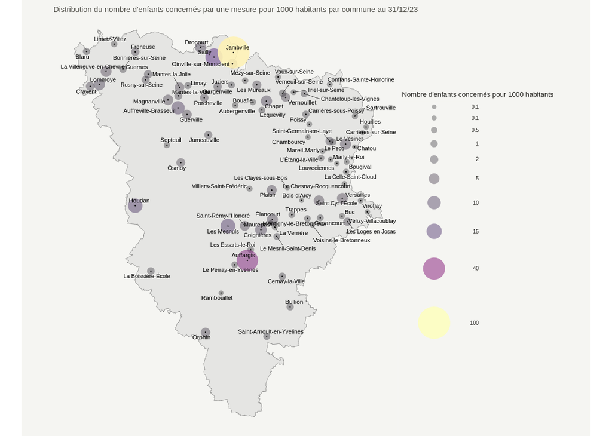

### Durée du parcours

La carte ci-dessous représente la durée médiane du parcours des enfants placés, par commune de résidence (nous avons privilégié la médiane à la moyenne pour atténuer le poids des éventuelles valeurs extrêmes pour une commune donnée). La durée du parcours correspond au nombre de jours écoulés entre la date de début de la mesure et sa date de fin (réelle lorsque les mesures sont achevées, théoriques lorsque celles-ci sont en cours).

Ces données mettent donc en lumière des besoins contrastés : les communes où les parcours sont les plus longs nécessitent une attention accrue pour mieux comprendre les obstacles à la sortie du dispositif et améliorer la coordination entre services sociaux, services sanitaires et solutions d’insertion. Les durées plus courtes pourraient traduire une meilleure réactivité, à condition qu’elles ne reflètent pas des ruptures de parcours non souhaitées potentiellement précipitées par une dégradation de l’état de santé mentale des enfants.

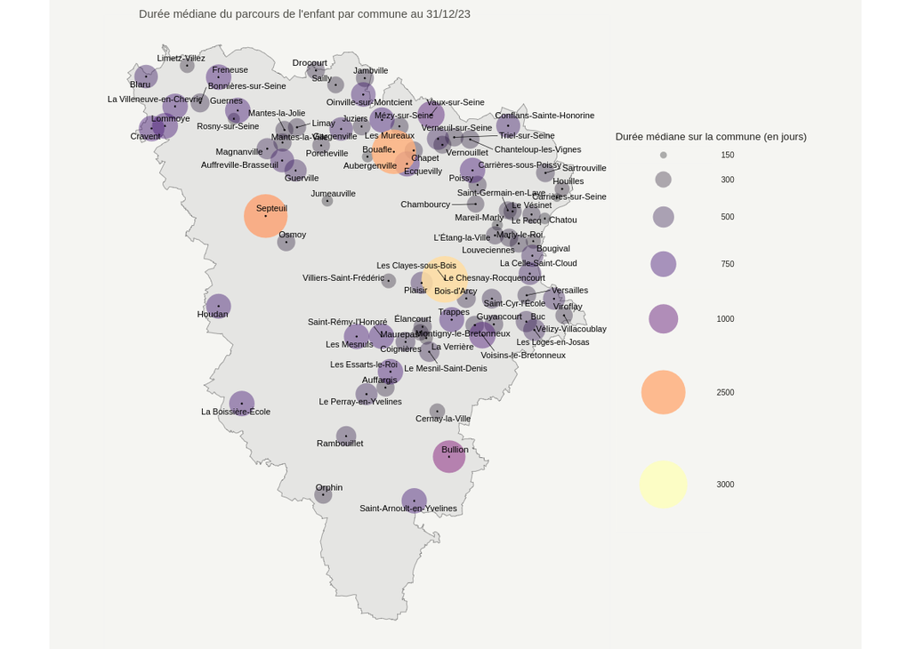

## Estimation des besoins en santé mentale des enfants placés

Pour l’heure, nous ne disposons pas de données départementales suffisamment nourries et/ou homogènes pour estimer le nombre d’enfants placés ayant un ou plusieurs besoins spécifique en santé mentale. Nous proposons néanmoins d’approximer ces besoins en appliquant les indices de prévalence extraits de la méta-analyse de Westlake et collaborateurs (2023, DOI: 10.1177/25161032231202256). Pour rappel, ce travail, le plus complet mené à ce jour sur la population des enfants placés, compile 27 études menées dans plusieurs pays européens (dont la France) et aux Etats-Unis. Il révèle qu’en moyenne, 46 % des enfants de 4 à 19 ans placés en foyer ou en famille d’accueil présentent au moins un trouble mental. Cette prévalence varie de 35 % à 57 % selon les études.

Les troubles les plus fréquents dans cette population sont les troubles externalisés (prévalence moyenne : 49 % ; intervalle de confiance à 95 % : 34 %-65 %), incluant les troubles oppositionnels, les troubles des conduites sociales et le trouble de l’attention/hyperactivité. Viennent ensuite les troubles internalisés (prévalence moyenne : 39 % ; intervalle de confiance à 95 % : 26 %-53 %), comprenant les troubles de l’humeur (dépression, troubles bipolaires, conduites suicidaires) et les troubles anxieux (anxiété généralisée, phobies spécifiques, troubles somatoformes).

A titre informatif, le tableau ci-dessous regroupe les prévalences estimées (moyennes et bornes inférieures/supérieures des intervalles de confiance associés) pour les troubles mentaux les plus fréquents chez les enfants et adolescents placés.

### Indices de prévalence extraits de Westlake et al, 2023

| Disorder | Taux de prévalence estimés Estimation Basse (95% CI) | Taux de prévalence estimés Estimation Moyenne | Taux de prévalence estimés Estimation Haute (95% CI) |
| --- | --- | --- | --- |
| Tout trouble du comportement | 0.35 | 0.46 | 0.58 |
| Troubles externalisés | 0.34 | 0.49 | 0.65 |
| Troubles internalisés | 0.26 | 0.39 | 0.53 |
| Troubles des conduites | 0.17 | 0.35 | 0.55 |
| Dépression | 0.18 | 0.26 | 0.35 |
| Symptômes émotionnels | 0.08 | 0.17 | 0.28 |
| Symtômes somatiques | 0.08 | 0.14 | 0.20 |

### Effectifs théoriques des enfants placés susceptibles d’exprimer un ou plusieurs troubles mentaux (année 2022)

Le graphique suivant présente une estimation globale des besoins actuels de prise en charge en santé mentale, combinant les effectifs d’enfants placés recensés sur le département des Yvelines en 2022 aux prévalences attendues pour les troubles mentaux rapportés dans la méta-analyse.

*NB : A première vue, il peut sembler incohérent que l’effectif présentant un trouble externalisé (spécifique) soit supérieur à l’effectif présentant tout type de troubles mentaux (aspécifique). Cela est simplement dû au fait que ces deux indices de prévalence sont obtenus à partir de corpus d’études différents. Par exemple, une étude peut renseigner un taux de prévalence spécifique (trouble externalisé) sans nécessairement renseigner un taux aspécifique (tout type de trouble), et vice versa.*

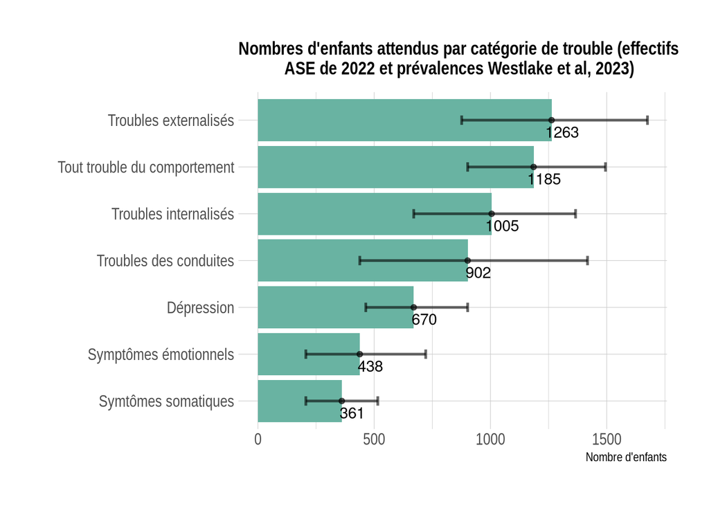

## Répartition territoriale des besoins théoriques en santé mentale

Nous avons utilisé l’indice de prévalence aspécifique moyen - présence d’au moins un trouble de santé mentale (46%) - afin d’estimer, pour chaque commune de résidence, le nombre d’enfants susceptibles d’exprimer au moins un besoin en santé mentale.

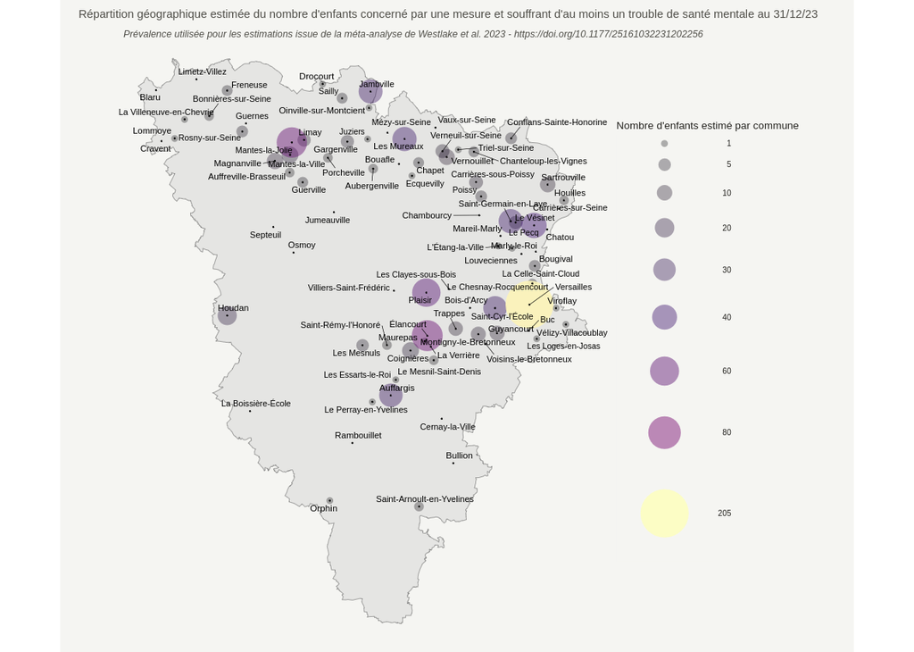

Les besoins théoriques en santé mentale estimés dans les sections précédentes reflètent des besoins immédiats. Néanmoins, il peut être utile d’envisager une adaptation prospective du dispositif de soin en santé mentale basée sur une prédiction des besoins futurs. Nous pouvons d’ores et déjà estimer ces besoins futurs effectifs théoriques en fonction de différents scenarii d’évolution de la population d’enfants placés (il nous appartiendra d’identifier dans un travail plus spécifique lequel de ces scenarii est le plus probable).

Le graphique représente l’historique des besoins théoriques en santé mentale (troubles externalisés, troubles internalisés), ainsi que leurs projections à 5 ans en fonction de différents scenarii.

Ces scenarii envisagent:

- une stagnation des effectifs
- différents taux d’augmentation
  - +10%
  - +15,5% (hausse maximale observée au cours de la période 2002-2022, pour la fenêtre 2017-2022)
  - +20%
- différents taux de diminution (-10%, -20%)
  - -9,4% (baisse maximale observée au cours de la période 2002-2022, pour la fenêtre 2003-2008)
  - -10%
  - -20%

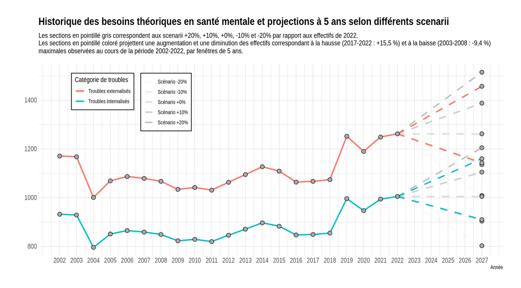

## Conclusion

Face à cette situation, les dispositifs de soin existants en santé mentale et en protection de l’enfance ont tous lieu d’être saturés, lorsqu’ils ne sont pas inégalement répartis sur le territoire. Les systèmes d’accueil, ainsi que l’offre de suivi psychologique et psychiatrique, pourraient peiner à répondre à l’ampleur de ces besoins, d’autant plus si leur croissance à venir est à l’image de celle observée depuis 2018 (voir graphique scenarii de projections).

Pour faire face à un possible engorgement de ces dispositifs, il apparaît essentiel de renforcer les structures de soin de proximité, de parfaire la coordination interinstitutionnelle entre l’ASE, les établissements de santé et les services sociaux, de développer des programmes de prévention et de dépistage précoce basés sur les preuves scientifiques (evidence-based), à destination des enfants et des familles, dans les écoles et les centres de santé. Enfin, le déploiement d’équipes pluridisciplinaires mobiles, composées de professionnels de santé mentale et d’éducateurs, pourrait permettre de mieux couvrir les zones les plus vulnérables, tout en apportant un soutien adapté aux enfants les plus fragiles.